# Sequential and Session-Based Recommendation

CP4285 Modern Recommendation Systems — Week 05

[figure not shown]

Scan for the slides  
soc-n.us/cp4285-t2610-w05

CP4285 Instruction Team

08 Sep 2026

# 01 Overview

##### Changelog

WEEK 04 RECAP

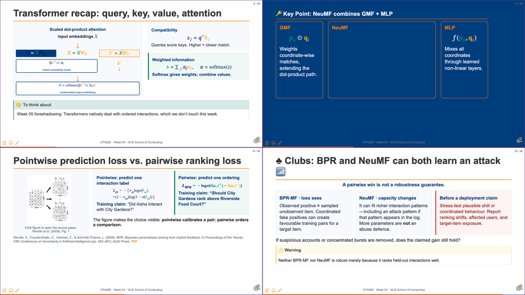

Last Week Pre-Lecture Exercise

Where Does One Session End?

[figure not shown]

[Optional reading: *The Straits Times*, 11 Aug 2026](https://www.straitstimes.com/singapore/google-rolls-out-updated-ai-powered-ask-maps-feature-in-singapore)

Canvas discussion board · post before Mon, 7 Sep 23:59 SGT

Post one **100–140 word** decision memo. No classmate reply is required.

A person asks Ask Maps for a 2pm lunch route, explores nearby cultural sites, then later asks for a halal eatery open after 10pm. Does the late-evening query begin a new session? Answer yes or no and cite two trace details.

Next week: sequences make order, recency, and local context part of the recommendation signal.

# 02 Sequence Models

## Ethics Thread: Engagement objectives

# Summary

## 🔑 Time changes what a preference signal means.

**Next week:** retrieval and ranking architectures.

Next Week Pre-Lecture Exercise

When Should the Current Session Outweigh History?

Canvas discussion board · post before Mon, 14 Sep 23:59 SGT

Post one **120–140 word** response. No classmate reply is required.

A user's long-term history is vegetarian cafés. In their current session, they search “late-night halal food”, open nearby restaurant pages, and check delivery times. What should the app consider now - and what should it not assume?

1. Name two item types the app should consider, even if the long-term profile would not prioritise them.
2. Explain one risk of treating this session as a permanent preference.
3. Name one **non-click** outcome that would show the list was helpful.

Next week: a system must make session-relevant options available before it can decide how to order the final list.

Next Week Preview — Week 06

Retrieval and Ranking Architectures

A production recommender cannot compare every catalogue item in one step. It first **retrieves** plausible candidates, then **ranks** and re-ranks the short list for the user and situation.

**In Week 06:**

- trace the candidate-generation → ranking → re-ranking pipeline;
- compare retrieval and ranking objectives; and
- examine two-tower architectures and visibility trade-offs.

[figure not shown]

[Photo: Barnabas Davoti / Unsplash](https://unsplash.com/photos/a-couple-of-dogs-playing-with-a-stuffed-animal-in-a-grassy-area-0lBR9AYzZ18)